# Statistics with R

The topics we will see on this course are under the category of **inferential statistics**: (1) Population and sample, (2) Point estimation, (3) Confidence intervals, (4) Hypothesis testing and (5) Linear regression. We will look at this topics theoretically and apllied in R.

# Distributions with R

## Normal distribution

Before, we have done some plots related to random variables. Now we’ll look at the density of a standard Gaussian

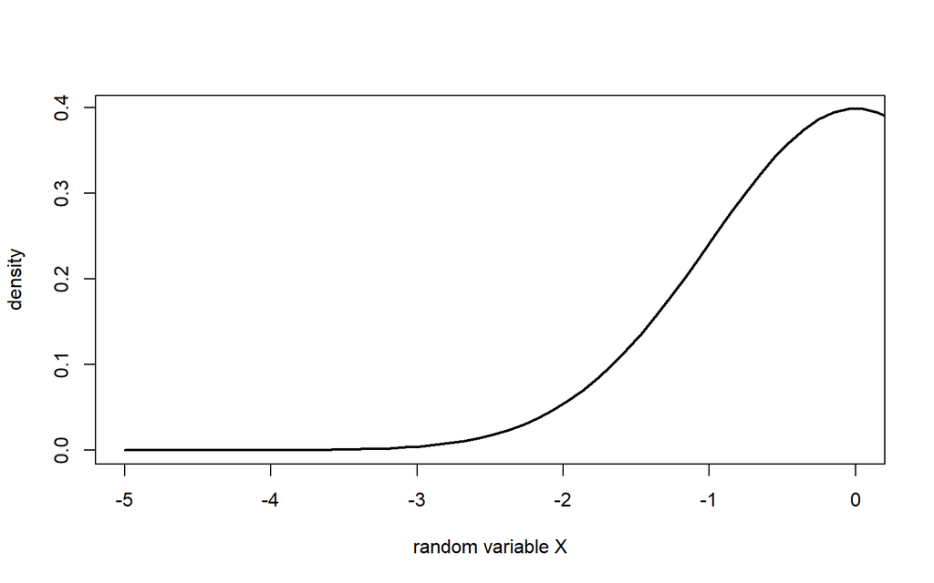

```r
#we specify the number of plot points
N = 100

#create a vector of N elements from -5 to 5
x = seq(-5,5, length=N)

#for the y axis
fz = dnorm(x)

#we plot:
plot(x, fz, #the data
     type="l",
     xlab = "random variable X",
     ylab = "density",
     xlim = c(-5,0), #we can focus our attention on only one part of the plot
     lwd=2 # defines the width of the line
     )
```

We can also do this in a more direct way:

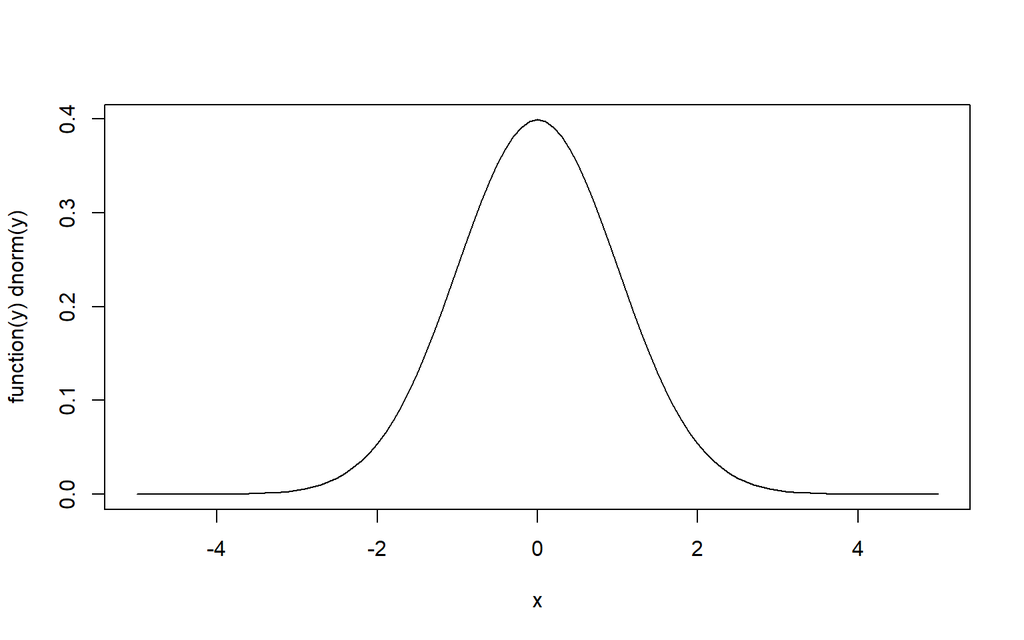

```r
plot(function(y)dnorm(y),#we create an annonymous function only inside of thje plot
     from=-5, to=5)
```

Similarly, we can plot the density of $X\thicksim N(3,5^2)$

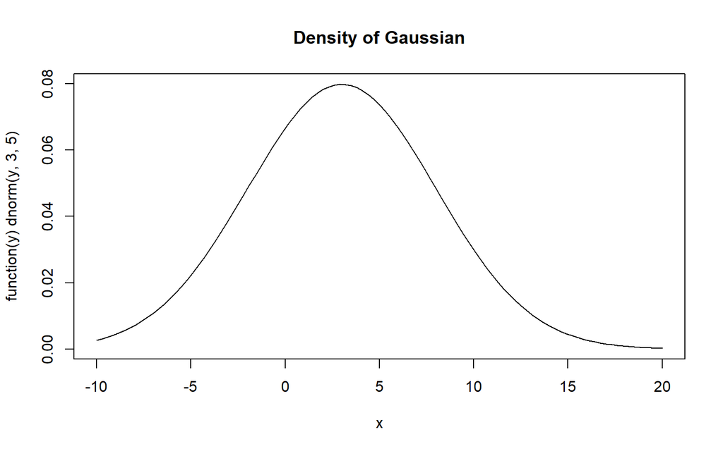

```r
plot(function(y)dnorm(y,3,5),
     from = -10, to=20,
     main = "Density of Gaussian")
```

Now we wish to draw more functions in the same plot in order to visualize the effect of an increase on parameters:

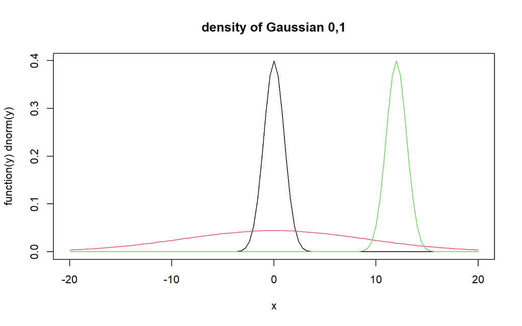

```r
# first N(0,1)
plot(function(y)dnorm(y),
     from = -20, to=20,
     main = "density of Gaussian 0,1",
     col=1 #color picked by number
     )
plot(function(y)dnorm(y, 0, 9),
     from = -20, to=20,
     main = "Density of Gaussians",
     col=2, #color picked by number
     add=T)
plot(function(y)dnorm(y, 12, 1),
     from = -20, to=20,
     col=3, #color picked by number
     add=T)
```

But, how does a histogram aprroximate to density?

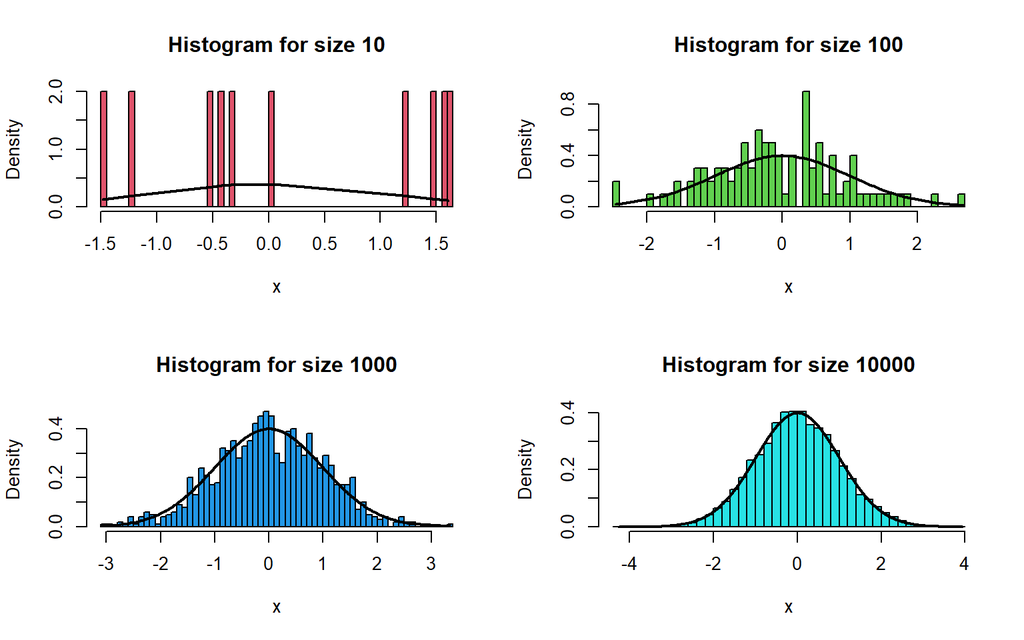

```r
values = c(10, 100, 1000, 10000) #we define sample sizes

par(mfrow=c(2,2))

for (n in values) {
  x = rnorm(n) # generate a n-random sample
  hist(x, 50, col=log(n,10)+1, freq=FALSE,
       main=paste("Histogram for size",n))
  #we use the lines function to impose a N(0,1) on the graph
  lines(sort(x),
        dnorm(sort(x)),
        col=1, lwd=2)
}
```

## Uniform distribution

Let’s replicate this for a uniform distribution $Y\thicksim U(3,7)$ using the sames values than before plus 100.000

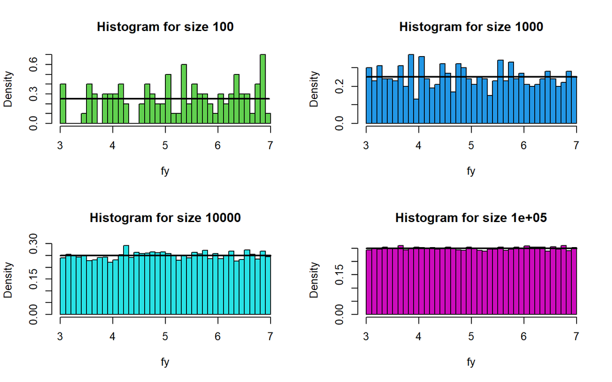

```r
values = c(100, 1000, 10000, 100000)

# Define parameters
a <- 3  # Min value
b <- 7  # Max value

par(mfrow=c(2,2))

# Create a loop
for (n in values) {
  fy = runif(n, a, b) # generate a n-random sample
  hist(fy, 50, col=log(n,10)+1, freq=FALSE,
       main=paste("Histogram for size",n))
  #we use the lines function to impose a N(0,1) on the graph
  lines(sort(fy),
        dunif(sort(fy), a, b),
        col=1, lwd=2)
}
```

# User defined functions

In R there are built-in functions like `dnorm(x)`. But we can also create new functions. Let’s create a function called MyFnc with 3 inputs and an output called out, wich performs some operations in the body {}.

```r
MyFnc = function(arg1,arg2,arg3){
  #statement1

  #statement2

  #statement3

  return(out) #we tell the output of the function
}
```

## Levy distribution

For example, we need a new fuction for evaluating the density of a Levy distribution.

```r
#we define the function
dlevy = function(x,th){
  #replicate the given math expression
  f = sqrt(th/(2*pi))*exp(-th/(2*x))*x^(-3/2)
  f = f*(x>0) #to impose the condition

  return(f)
}
#now dlevy is a function in our evironoment.

#we evaluate the function on x=5 ,th=2
dlevy(5, 2)
```

```
## [1] 0.04131532
```

Now that we have created our `dlevy(x,th)` function, we can plt the Levy pdf

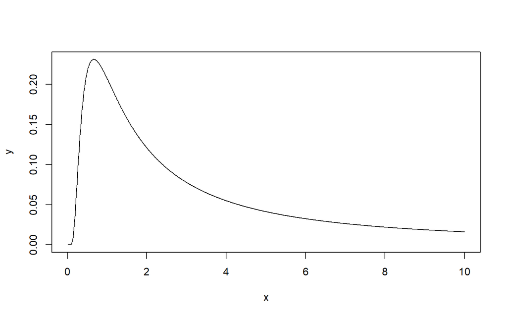

```r
par(mfrow=c(1,1))

x = seq(0.01,10, by=0.01)
y = dlevy(x,2)

plot(x,y,
     type="l")
```

We can redifine `dlevy` with default values to use similarly to the `dnorm` function

```r
#we define the function
dlevy = function(x=0,th=1){
  #replicate the given math expression
  f = sqrt(th/(2*pi))*exp(-th/(2*x))*x^(-3/2)

  #impose the condition x>0 because if the logal operator x>0 is false -> f=0
  f = f*(x>0)

  return(f)
}
#now dlevy is a function in our evironoment.

#we evaluate the function on x=5 ,th=1
dlevy(5)
```

```
## [1] 0.03228685
```

## Laplace distribution

Now we are going to create a function for a Laplace density function:

```r
dlaplace = function(x,th){
  #th will be a vector containing both arguments
  mu = th[1]
  b = th[2]

  #replicate the given math expression
  f = 1/(2*b)*exp(-abs(x-mu)/b)

  #impose the condition x>0 because if the logal operator b>0 is false -> f=0
  f = f*(b>0)

  return(f)
}

#we evaluate on x=5 , mu=0 , b=1
dlaplace(5, c(0,1))
```

```
## [1] 0.003368973
```

# Central Limit Theorem (CLT)

We’ll try to see how the CLT works on different distributions and sample sizes.

We know if we have $n$ random variables $X$ with unknown distribution and $E(X)=\mu$, $V(X)=\sigma^2$, ($n>50$) then the sum of each RV:

$$\sum_{i=1}^{n}{X_i}\approx
N(n\mu,n\sigma^2)$$
Let’s say we have $X\thicksim U(0,1)$ then, we know by the uniform properties than $E(X)=1/2$ and $V(X)=1/12$.

```r
# sample size
n=2

# Number of simulations
M = 10000

#generate the rvs
X = runif(M*n, #number of observations
          min=0, max=1)
```

Now we generate a matrix were the columns are $n$ random variables with uniform distribution (0,1) and the rows are the extractions for each one of those variables.

```r
# X as a matrix
XMat = matrix(X,   #fill the matrix with the values of X
              nr=M, #Number of rows
              nc=n #number of columns
              ) #Note: we do not care about the other on wich the matrix is filled
```

$$Y=\sum_{i=1}^{n=2}{X_i}\approx
N(n/2,n/12)$$

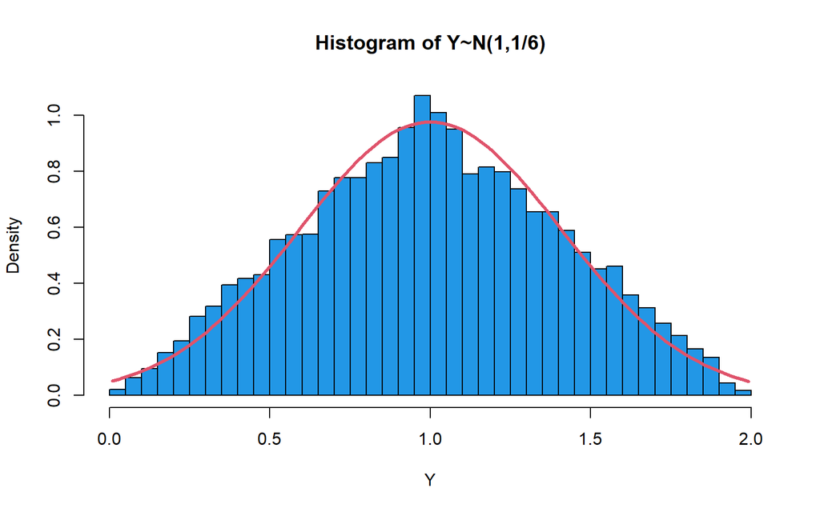

```r
#sum row by row
Y = rowSums(XMat)
#Y = apply(Xmat,1,sum) #equivalent function

#histogram of sum
hist(Y, 50, col=4, prob=TRUE,
     main="Histogram of Y~N(1,1/6)")

#we add a normal with the same parameters to compare.
plot(function(x)dnorm(x, n/2, sqrt(n/12)),
     add=TRUE, col=2, lwd=3, xlim=range(Y))
```

We can see that, in the case of a uniform distribution, even with a sample of n=2, the normal distribution is a good aproximmation for the distribution of it’s sum (and mean).

## Different levels of n

Now we will see the CLT for the sum of n uniforms

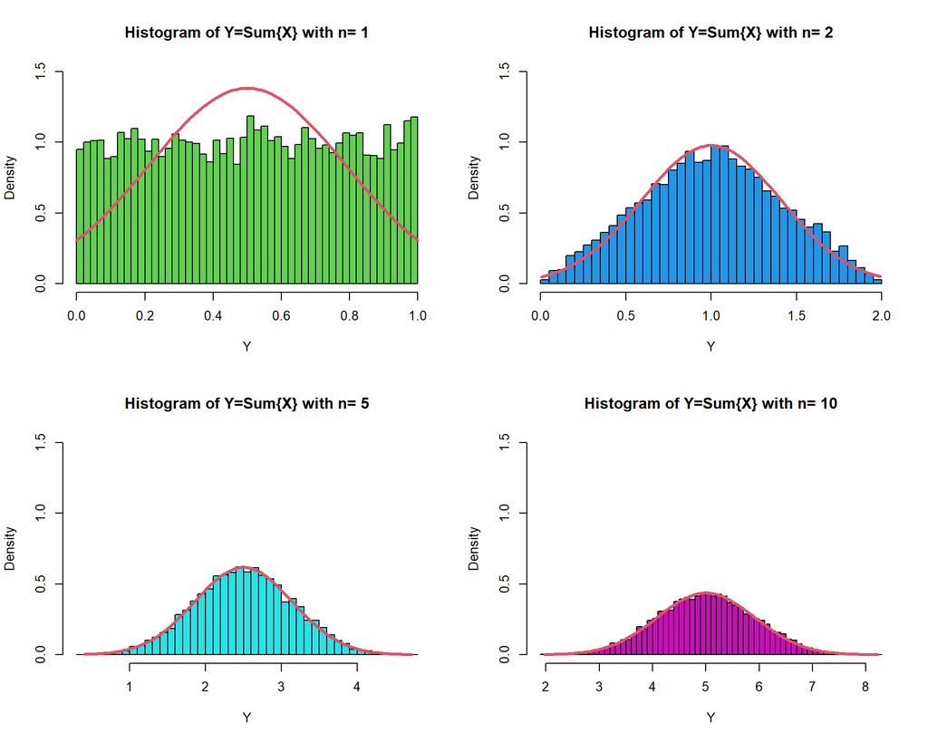

```r
par(mfrow=c(2,2))
M=10000 # Number of simulations

v = c(1,2,5,10) # sample sizes to sum

#loop
for(n in v){
  #generate the rvs
  X = runif(M*n)

  # X as a matrix
  XMat = matrix(X,   #fill the matrix with the values of X
               nr=M, #Number of rows
               nc=n #number of columns
               ) #Note: we do not care about the other on wich the matrix is filled

  #sum row by row
  Y = rowSums(XMat)
  #Y = apply(Xmat,1,sum)

  #histogram of sum
  hist(Y, 50, col=(which(v %in% n)+2), prob=TRUE, ylim=c(0,1.5),
       main= paste("Histogram of Y=Sum{X} with n=", n)
       )

  plot(function(x)dnorm(x, n/2, sqrt(n/12)),
       add=TRUE, col=2, lwd=3, xlim=range(Y))
}
```

## Sample variance

We know that for a generic population the sample variance is given by

$$s^2=\frac{\sum(X_i-\bar X)^2}{n-1}
\text{ and thus: } \frac{(n-1)s^2}{\sigma^2}\thicksim
\chi^2_{n-1}$$
Now, let’s say that we have the probability $Pr(s^2>3)$ where $s^2$ is the sample variance, when $X\thicksim N(3,4)$ and the sample size of our realization is $n=7$

$$\frac{(7-1)s^2}{4}
\thicksim \chi^2_{7-1}$$
Then $Pr(s^2>3)=1-Pr(s^2<3)$

```r
#exact value of the pdf of chi square
1 - pchisq(18/4, 6)
```

```
## [1] 0.6093393
```

If we want to evaluate $Pr(S^2>3)$ without using $\chi^2$, when $X \thicksim N (3,4)$ and $n=7$ we’ll use a *Montecarlo Procedure*

```r
#number of simulations
M = 10000

#population parameters
Mu =3
Sigma = 2
n = 7

#Innefficient code for montecarlo TO DO: efficient way

#counter of number of times S^2>3
C = 0

for (i in 1:M) {
  #extract a sample
  x = rnorm(n, Mu, Sigma)

  #compute sample variance (the function in r uses the sample variance formula)
  s2 = var(x)

  #we update our counter if the contidion is true
  if(s2>3){
    C = C+1
  }
}

C/M
```

```
## [1] 0.608
```

An alternative to get the same result

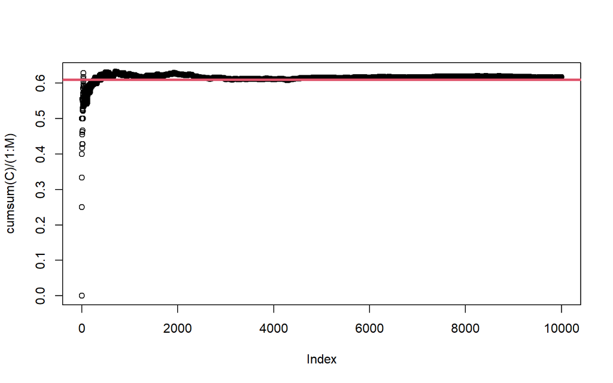

```r
#replacement of the counter
C = rep(0,M)

#we will fill it by 1 when S^2>3
for (i in 1:M) {
  #extract a sample
  x = rnorm(n, Mu, Sigma)

  #compute sample variance (the function in r uses the sample variance formula)
  s2 = var(x)

  #we update our vector if the contidion is true
  if(s2>3){
    C[i]=1
  }
}

#the advantage is that we can see the evolution of C
plot(cumsum(C)/(1:M)) #cumulative mean
abline(h=1-pchisq(18/4, 6), col=2, lwd=3)
```

This plot can be used as a guidance for fixing M once it stabilizes. For example, with the graph we can see that we do not need 10.000 simulations, but only 2.000.

A third approach would be

```r
#we create a vector to be filled
Z = c()

#we will fill it by 1 when S^2>3
for (i in 1:M) {
  #extract a sample
  x = rnorm(n, Mu, Sigma)

  #compute sample variance (the function in r uses the sample variance formula)
  s2 = var(x)

  #we update our vector if the contidion is true
  if(s2>3){
    Z = c(Z,1)
  }else{
    Z = c(Z,0)
  }
}
```

Let’s create a function for computing the pooled sample variance

```r
#for two RV: x and y
poolvar = function(x,y){
  #retieve the sample sizes
  n=length(x)
  m=length(y)

  #compute the weight of x relative to y
  alpha=(n-1)/(n+m-2)

  #pooled sample variance
  S2 = alpha*var(x)+(1-alpha)*var(y)

  return(S2)
}

sample1 = rnorm(100,0,1)
sample2 = rnorm(50,0,2) #note less size and higher variance


poolvar(sample1, sample2)
```

```
## [1] 1.937719
```

we can get different results but we must always have TRUE on the following condition

```r
var(sample1) < poolvar(sample1, sample2) & poolvar(sample1, sample2) < var(sample2)
```

```
## [1] TRUE
```

# Maximum Likelihood Estimator (MLE)

We retrieve the ML estimator for the intermediate case where $(x_1,x_2,x_3)=(1,0,1)$ we had already estimated that $\hat p=2/3)0,66$

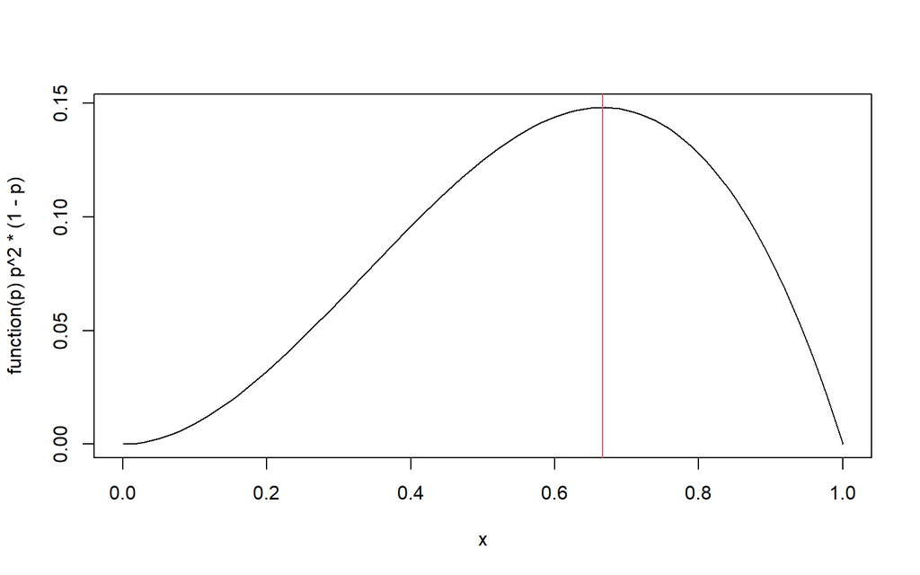

```r
#we plot the function of the Likelihood
plot(function(p)p^2*(1-p))
abline(v=2/3, col=2)
```

Now we want to program a user defined function to compute the following matemathical function:

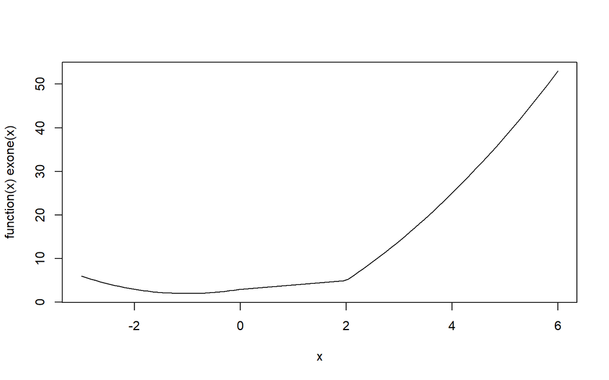

```r
#create the function
exone = function(x){
  fx = ifelse(x < 0,
              x^2 + 2*x + 3,
              ifelse(x < 2,
                     x + 3,
                     x^2 + 4*x - 7))
  return(fx)
}

#we evaluate
plot(function(x)exone(x), from=-3, to=6)
```

## Function optimum

`optimum` is the function we use for numerical optimization. Inputs:

1. Initial value (arbitrary but reasonable)
2. function to maximize
3. min / max
4. other inputs of the function

We aim to find the mode of a gamma distribution (the point x* at which pdf/pmf is max). Note: A gamma distribution is useful for positive, continuous rvs.

```r
#compute the function oprtim por a gamma distribution
optim(1, #initial value
      dgamma, #function to maximize
      control=list(fnscale=-1), #with this we maximize (since optim usually minimizes)
      shape=2, rate=2 #parameters needed by function dgamma
      )
```

```
## $par
## [1] 0.5
##
## $value
## [1] 0.7357589
##
## $counts
## function gradient
##       30       NA
##
## $convergence
## [1] 0
##
## $message
## NULL
```

The output we obtain is a list, **par** is the maximum or minimum point we were looking for (x* ), **value** is the oprtimized value of f, that is f(x* ), **counts** is the number of iterations to convergence, **gradient** depends on the algorith we choose, but reflects the approximation of the first derivative. Finally, **convergence** is a sort of check, if it’s 0 everything was ok with the process and we get no **message**.

In sum, the mode is $0.5$ and we know that the exact mode for a gamma distribution is given by:

$$\frac{shape-1}{rate}=\frac{2-1}{2}=0.5$$

In this example we have a comparison with the analytical solution, but some other times we do not have this comparison.

Now, we want to find the optimum point for the function

$$f(x,y)=x-1+\frac{3.2}{y}+ln[\Gamma(x)]+3x*ln(y)$$
As there is not such function in R we must create it

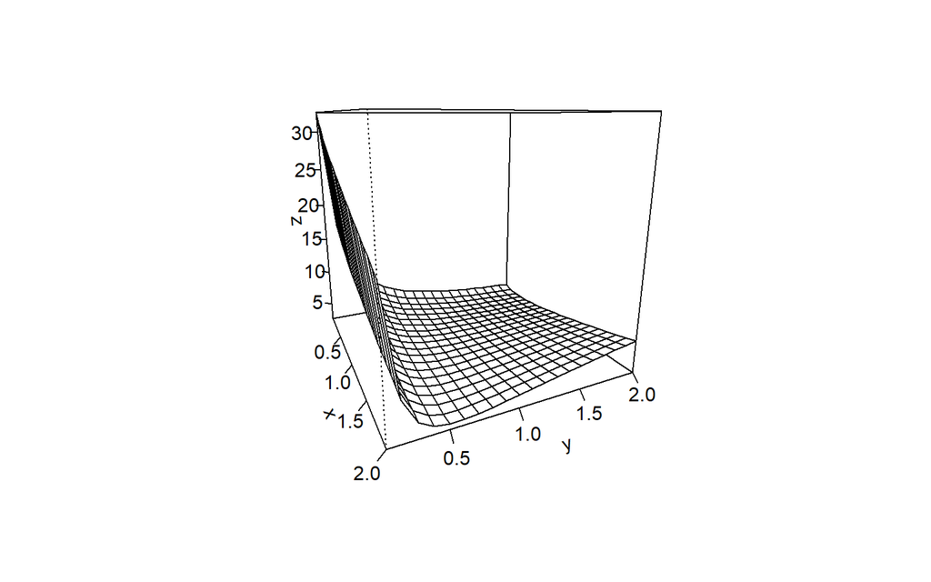

```r
#create the function
f1 = function(x,y){
  z = x-1+(3.2/y)+log(gamma(x))+3*x*log(y)
  return(z)
}

#create an x axis
x = seq(0.1,
        2,
        by= 0.1)

#create y-axis
y = x

#evaluate the f1 at each possible couples of x and y (z-axis)
z = outer(x,y,f1)

persp(x, y, z,
      ticktype = "detailed",
      theta=65 #rotate the plot
      )
```

As such `f1` is defined in a useful manner to plot, but not for optim since `optim` uses only the first argument of the function.

Then, let’s modify f1.

```r
f2 <- function(theta){
  x = theta[1]
  y = theta[2]

  z = x-1+(3.2/y)+log(gamma(x))+3*x*log(y)
  return(z)
}
```

now we can use optim to minimize our function:

```r
optim(c(1,1),
      f2)
```

```
## $par
## [1] 0.155576 6.857680
##
## $value
## [1] 2.31019
##
## $counts
## function gradient
##      179       NA
##
## $convergence
## [1] 0
##
## $message
## NULL
```

## Normal Likelihood and logLikelihood

Now we create a function for likelihood in the gaussian case $N(\mu, \sigma^2)$. We want the output to be $L(\mu, \sigma, sample)$

```r
#function definition
NormLik = function(mu,sigma,x){
  fxi <- dnorm(x, mu, sigma) #densities
  L <- prod(fxi) #likelihood
  return(L)
}

#sample
collected.data=rnorm(5,1,2)

#evaluate
c(NormLik(1,2,collected.data),
  NormLik(10,2,collected.data) #smaller
)
```

```
## [1] 6.613615e-06 1.331205e-28
```

But, if we try it on a larger sample:

```r
#size 1000
collected.data2=rnorm(1000,1,2)

#evaluate
c(NormLik(1,2,collected.data2),
  NormLik(10,2,collected.data2)
)
```

```
## [1] 0 0
```

As the results tend to 0 we are not able to discriminate between different parameter values. To adress this issue we turn then to log-likelihood

```r
#function definition
NormLogLik = function(mu,sigma,x){
  fxi <- dnorm(x, mu, sigma) #densities
  lfxi <- log(fxi) #log-densities
  logL <- sum(lfxi)
  return(logL)
}

#evaluate
c(NormLogLik(1,2,collected.data2),
  NormLogLik(10,2,collected.data2))
```

```
## [1]  -2103.875 -12196.025
```

Thanks to this process we are able to discriminate between different parameter values, and $\mu=1$ has much higher loglik.

Yet, to be able to optimize the parameters we need to aggregate them into a unique vector.

```r
#function definition
NormLogLik2 = function(theta,x){
  mu=theta[1]
  sigma=theta[2]

  fxi <- dnorm(x, mu, sigma) #densities
  lfxi <- log(fxi) #log-densities
  logL <- sum(lfxi)
  return(logL)
}

#eval
c(NormLogLik2(c(1,2),collected.data2),
  NormLogLik2(c(10,2),collected.data2)
)
```

```
## [1]  -2103.875 -12196.025
```

## MLE Exponential

Let’s write a function for exponential loglik and then plot the loglik from 0 to 2, for the given sample $x=(1,2,7,2,3)$

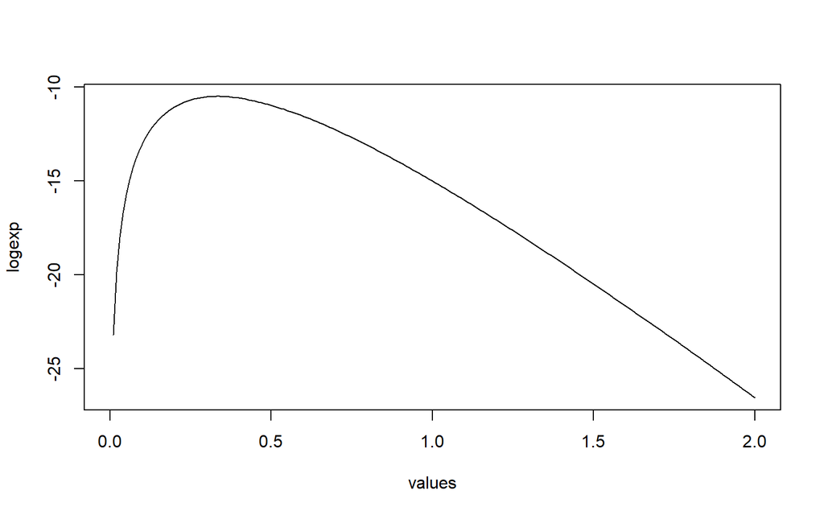

```r
ExpLogLik = function(lam, x){
  fxi <- dexp(x, lam) #densities
  lfxi <- log(fxi) #log-densities
  logL <- sum(lfxi)
  return(logL)
}

values = seq(0,
        2,
        by= 0.01)
x=c(1,2,7,2,3)

logexp = c()

for (i in 1:length(values)) {
  logexp[i] = ExpLogLik(values[i],x) #log-lik evaluated at the i-element of lams
  }

plot(values, logexp, type="l")
```

If we look for the MLE of $lambda$, note that in this context `optim` has the additional inputs

```r
sampled.data=rexp(10,0.2)
MLE <- optim(0.1,
      ExpLogLik,
      control=list(fnscale=-1),
      x=sampled.data)
lam.mun <- MLE$par
lam.mun
```

```
## [1] 0.3871094
```

```r
lamhat = 1/mean(sampled.data)
lamhat
```

```
## [1] 0.3871466
```

## MLE for Normal

Now let’s find the MLE for $\mu$ and sigma in a Gaussian population, then compare numerical and analytically solution on `xvec = rnorm(1000,10,2)`

```r
#we already have the NormLogLik2 function, we optimize to find the MLE for mu
xvec=rnorm(1000,10,2)

MLE2 = optim(c(0,1),
      NormLogLik2,
      control=list(fnscale=-1),
      x=xvec)
theta.mle <- MLE2$par
theta.mle
```

```
## [1] 9.932092 1.948970
```

```r
muhat = mean(xvec)
muhat
```

```
## [1] 9.931377
```

```r
sigmahat=sqrt(((1000-1)/1000)*var(xvec))
sigmahat
```

```
## [1] 1.94915
```

Next time: couple of final examples on MLE with a real data vector and on a second example we will see MLE for a used defined pdf.

## MLE on Gamma

We will find estimates of $\alpha$ and $\beta$ for $x \thicksim \Gamma(\alpha,\beta)$, where $X$ is the closing prince of Apple stock.

```r
# Read de dataframe we will use from the folder data on my working directory
data = read.csv(paste0(mypath,"//Apple.csv")
                          , sep=",")

#store on environment the closing price
x = data$Close

#define a function to obtain the log-likelihood for a gamma function.
Gll = function(theta, x){
  #define pdf
  f = dgamma(x, shape=theta[1], scale=theta[2]) #we can choose rate OR scale

  #log-likelihood
  ll = sum(log(f))

  return(ll)
}

MLE.gamma <- optim(c(1,1),
                   Gll,
                   control=list(fnscale=-1),
                   x=x)

MLE.gamma$par
```

```
## [1] 330.537853   1.656764
```

Then, if we want to compute the probability that the price is below 550

```r
pgamma(550, MLE.gamma$par[1], scale=MLE.gamma$par[2])
```

```
## [1] 0.5386847
```

Now we wish to find the MLE of pars of Kumaraswami distribution, a generalization of the unifor, with two parameters a and b. It reduces to the uniform when a=b=1. We need to do the following steps:

1. function for pdf
2. definition for log-likelihood
3. oprtimization for ll

```r
#TO DO: define errors when parameters do not met conditions
dKuma <- function(x,a,b){
  #definition of the PDF
  fx =a*b*(x^(a-1))*((1-(x)^a))^(b-1)
}

Kll = function(theta, x){
  #define pdf
  f = dKuma(x, a=theta[1], b=theta[2]) #we can choose rate OR scale

  #log-likelihood
  ll = sum(log(f))

  return(ll)
}

#define the sample
unifsample = runif(100, 0, 1)

MLE.Kuma = optim(c(0.01,0.01),
                   Kll,
                   control=list(fnscale=-1),
                   x=unifsample)

MLE.Kuma$par
```

```
## [1] 0.7971054 0.8136944
```

values for a, and b close to one make sence since obs has been generated from an uniform and we know that kumawasaki tends to a uniform when a=b=1.

# Method of Moments

Let’s find the MM esttimates for a Binomial distribution

```r
set.seed(12345)

#sample size
n=4

#Binomial paramethers
N = 10
p = 0.1

#Binomial random sample
x=rbinom(n,N,p)

#MM estimates
xbar = mean(x)
N.tilde = xbar^2/(xbar-sum((x-xbar)^2)/n)
p.tilde = xbar/N.tilde

theta = c(xbar, N.tilde, p.tilde)
theta
```

```
## [1] 1.7500000 1.9600000 0.8928571
```

now lets try with increasing n

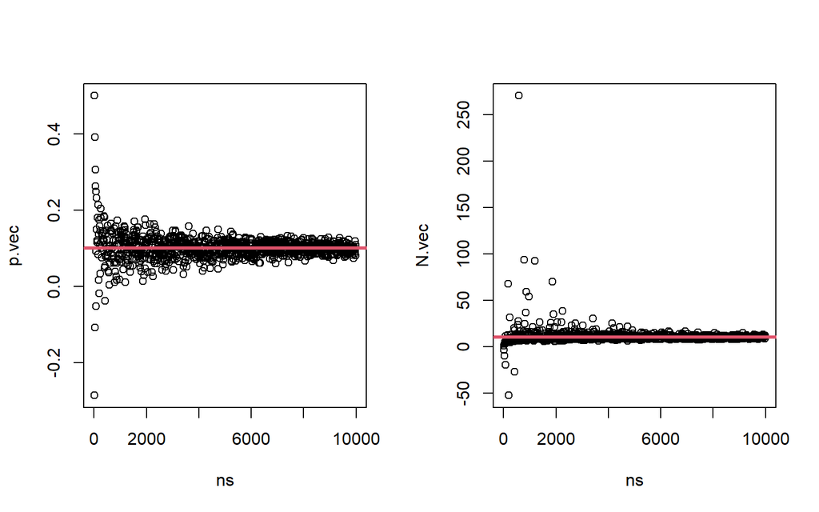

```r
ns=seq(4,10000,by=10) #samples sizes we will try

#empty vector to fill
p.vec = c()
N.vec = c()

for (n in ns) {
  x = rbinom(n,N,p)

  #compute MM estimates
  xbar = mean(x)
  N.tilde = xbar^2/(xbar-sum((x-xbar)^2)/n)
  p.tilde = xbar/N.tilde

  #store the estimates
  p.vec = c(p.vec, p.tilde)
  N.vec = c(N.vec, N.tilde)
}

par(mfrow=c(1,2))

#plot for p
plot(ns, p.vec)
abline(h=p,
       col=2,
       lwd=3)
#plot for n
plot(ns, N.vec)
abline(h=N,
       col=2,
       lwd=3)
```

# Confidence Intervals

## Normal distribution and known variance

We are in need of a function to compute $CI_(1-\alpha)(\mu)$ for a random variable $X \thicksim N(\mu, \sigma ^2)$ where $\sigma$ is known.

As inputs then we have the sampled data, the level of confidence, the population variance and we need to estimate the confidence interval for the unknown parameter.

```r
#customized function
Normal_CI <- function(x, lvl=0.95, sigma=1){

  #known parameters
  alpha = 1-lvl
  n = length(x)

  #---------list to be filled
  params <- list(1,2,3,4,5)
  param_names <- c("Computed values",
                   "Lower bound", "Upper bound",
                   paste0("Confidence Interval at ",lvl*100,"%"),
                   "CI width")
  names(params) <- param_names

  #computed values
  z = qnorm(1-alpha/2)
  MoE = z*sigma/sqrt(n) #margin of error
  avg = mean(x)

  comp = c(avg, sigma, z,MoE)
  names(comp) = c("Sample Mean", "Population SD", "Z-quantile", "Margin of Error")
  params[[1]] <- comp

  #lower bound
  L1 = avg-MoE
  params[[2]] <- L1

  #upper bound
  L2 = avg+MoE
  params[[3]] <- L2

  #Confidence intercal
  CI = c(L1, L2)
  params[[4]] <- CI

  #width
  w <- diff(CI)
  params[[5]] <- w

  return(params)
}

#generate a random sample
x = rnorm(16, 25, sd=sqrt(36))

#eval
a <- Normal_CI(x, sigma=sqrt(36))
a
```

```
## $`Computed values`
##     Sample Mean   Population SD      Z-quantile Margin of Error
##       23.663629        6.000000        1.959964        2.939946
##
## $`Lower bound`
## [1] 20.72368
##
## $`Upper bound`
## [1] 26.60358
##
## $`Confidence Interval at 95%`
## [1] 20.72368 26.60358
##
## $`CI width`
## [1] 5.879892
```

We can check how the CI changes as we modify our level of confidence:

```r
#eval
b <- Normal_CI(x, lvl=0.99, sigma=sqrt(36))
b
```

```
## $`Computed values`
##     Sample Mean   Population SD      Z-quantile Margin of Error
##       23.663629        6.000000        2.575829        3.863744
##
## $`Lower bound`
## [1] 19.79989
##
## $`Upper bound`
## [1] 27.52737
##
## $`Confidence Interval at 99%`
## [1] 19.79989 27.52737
##
## $`CI width`
## [1] 7.727488
```

As we lost certanty we won’t be able to use $z$ (normal distribution) anymore, instead we must use $t$.

```r
#customized function
unkNormal_CI <- function(x, lvl=0.95){

  #known parameters
  alpha = 1-lvl
  n = length(x)

  #---------list to be filled
  params <- list(1,2,3,4,5)
  param_names <- c("Computed values",
                   "Lower bound", "Upper bound",
                   paste0("Confidence Interval at ",lvl*100,"%"),
                   "CI width")
  names(params) <- param_names

  #computed values
  avg = mean(x)
  s = sd(x)
  T = qt(1-alpha/2, n-1)
  MoE = T*s/sqrt(n) #margin of error

  comp = c(avg, s, T, MoE)
  names(comp) = c("Sample Mean", "Sample SD", "T-quantile", "Margin of Error")
  params[[1]] <- comp

  #lower bound
  L1 = avg-MoE
  params[[2]] <- L1

  #upper bound
  L2 = avg+MoE
  params[[3]] <- L2

  #Confidence intercal
  CI = c(L1, L2)
  params[[4]] <- CI

  #width
  w <- diff(CI)
  params[[5]] <- w

  return(params)
}
```

```r
#eval
unkNormal_CI(x)
```

```
## $`Computed values`
##     Sample Mean       Sample SD      T-quantile Margin of Error
##       23.663629        5.491196        2.131450        2.926052
##
## $`Lower bound`
## [1] 20.73758
##
## $`Upper bound`
## [1] 26.58968
##
## $`Confidence Interval at 95%`
## [1] 20.73758 26.58968
##
## $`CI width`
## [1] 5.852103
```

There is actually a build-in function on r to perform this calculus:

```r
t.test(x, conf.level = 0.95)
```

```
##
##  One Sample t-test
##
## data:  x
## t = 17.238, df = 15, p-value = 2.687e-11
## alternative hypothesis: true mean is not equal to 0
## 95 percent confidence interval:
##  20.73758 26.58968
## sample estimates:
## mean of x
##  23.66363
```

We can use the `t.test()` function in any case were we have normal distributions and unknown parameters.

## Bernoulli asymptotic CI

A CI for large samples on the case of a Bernoulli. On this case the input we have are the sumber of sucesses, the sample size and the confidence level.

```r
#customized function
Ber_AsyCI <- function(suc, n, lvl=0.95){

  #known parameters
  alpha = 1-lvl

  #---------list to be filled
  params <- list(1,2,3,4,5)
  param_names <- c("Computed values",
                   "Lower bound", "Upper bound",
                   paste0("Confidence Interval at ",lvl*100,"%"),
                   "CI width")
  names(params) <- param_names

  #computed values
  prop = suc/n
  var = prop*(1-prop)
  z = qnorm(1-alpha/2)
  MoE = z*sqrt(var)/sqrt(n) #margin of error

  comp = c(prop, sqrt(var), z, MoE)
  names(comp) = c("Sample Mean", "Sample SD", "z-quantile", "Margin of Error")
  params[[1]] <- comp

  #lower bound
  L1 = prop-MoE
  params[[2]] <- L1

  #upper bound
  L2 = prop+MoE
  params[[3]] <- L2

  #Confidence intercal
  CI = c(L1, L2)
  params[[4]] <- CI

  #width
  w <- diff(CI)
  params[[5]] <- w

  return(params)
}

#generate random sample
ber <- rbinom(344, 1, 0.24)

#eval
Ber_AsyCI(sum(ber), 344, lvl=0.9)
```

```
## $`Computed values`
##     Sample Mean       Sample SD      z-quantile Margin of Error
##      0.21511628      0.41090299      1.64485363      0.03644075
##
## $`Lower bound`
## [1] 0.1786755
##
## $`Upper bound`
## [1] 0.251557
##
## $`Confidence Interval at 90%`
## [1] 0.1786755 0.2515570
##
## $`CI width`
## [1] 0.0728815
```

## Normal asymptotic CI

As we stated before, on the case on unkwnown parameters we can use the `t.test()` function. Let’s explore this aproximation with the *Apple.csv* dataset.

```r
data = read.csv(paste0(mypath,"//Apple.csv")
                          , sep=",")
x = data$Open
y = data$Close

#t test with two samples
t.test(x, y, conf.level = 0.95,
       var.equal = TRUE #if we assume equal variances
       )
```

```
##
##  Two Sample t-test
##
## data:  x and y
## t = -0.15492, df = 154, p-value = 0.8771
## alternative hypothesis: true difference in means is not equal to 0
## 95 percent confidence interval:
##  -10.345385   8.840768
## sample estimates:
## mean of x mean of y
##  546.8653  547.6176
```

As we can see the confidence interval includes both negative and positive values, so we can conclude that there is not evidence to state that *Open* is higher than *Close* or viceversa. Also, as the length of *data* es $78$ we can notice that $df=154 = 78+78-2$.

```r
#t test with two samples
t.test(x, y, conf.level = 0.95,
       var.equal = FALSE
       )
```

```
##
##  Welch Two Sample t-test
##
## data:  x and y
## t = -0.15492, df = 153.9, p-value = 0.8771
## alternative hypothesis: true difference in means is not equal to 0
## 95 percent confidence interval:
##  -10.345436   8.840819
## sample estimates:
## mean of x mean of y
##  546.8653  547.6176
```

In consequence we must ask ourselves: is it reasonable to assume equal variances?

```r
#compute CI for sigma_1^2/sigma_2^2
var.test(x,y,conf.level = 0.99)
```

```
##
##  F test to compare two variances
##
## data:  x and y
## F = 0.94933, num df = 77, denom df = 77, p-value = 0.8201
## alternative hypothesis: true ratio of variances is not equal to 1
## 99 percent confidence interval:
##  0.5245339 1.7181510
## sample estimates:
## ratio of variances
##          0.9493306
```

As the CI provided by this test includes the value 1 we can a assume (with a 99% confidence level) that the variances are equal.